# p8105_hw6_my2644

ymysherry

12/9/2020

## Problem 1

```r
homicide_df =
  read_csv("data/homicide-data.csv", na = c("", "NA", "Unknown")) %>%
  mutate(
    city_state = str_c(city, state, sep = ", "),
    victim_age = as.numeric(victim_age),
    resolution = case_when(
      disposition == "Closed without arrest" ~ 0,
      disposition == "Open/No arrest"        ~ 0,
      disposition == "Closed by arrest"      ~ 1
    )
  ) %>%
  filter(
        victim_race %in% c("White", "Black"),
  city_state != "Tulsa, AL") %>%
  select(city_state, resolution, victim_age, victim_race, victim_sex)
```

start with one city

```r
baltimore_df=
    homicide_df %>%
  filter(city_state == "Baltimore, MD")

glm(resolution ~ victim_age + victim_race + victim_sex,
    data = baltimore_df,
    family = binomial()) %>%
  broom::tidy() %>%
  mutate(
    OR = exp(estimate),
    CI_lower = exp(estimate - 1.96 * std.error),
    CI_upper = exp(estimate + 1.96 * std.error)
  ) %>%
  select(term, OR, starts_with("CI")) %>%
  knitr::kable(digits = 3)
```

| term | OR | CI_lower | CI_upper |
| --- | --- | --- | --- |
| (Intercept) | 1.363 | 0.975 | 1.907 |
| victim_age | 0.993 | 0.987 | 1.000 |
| victim_raceWhite | 2.320 | 1.648 | 3.268 |
| victim_sexMale | 0.426 | 0.325 | 0.558 |

Try this across cities.

```r
models_results_df =
  homicide_df %>%
  nest(data = -city_state) %>%
  mutate(
     models =
      map(.x = data, ~glm(resolution ~ victim_age + victim_race + victim_sex, data = .x, family = binomial())),
    results = map(models, broom::tidy)
  ) %>%
  select(city_state, results) %>%
  unnest(results) %>%
  mutate(
    OR = exp(estimate),
    CI_lower = exp(estimate - 1.96 * std.error),
    CI_upper = exp(estimate + 1.96 * std.error)
  ) %>%
  select(city_state, term, OR, starts_with("CI"))
```

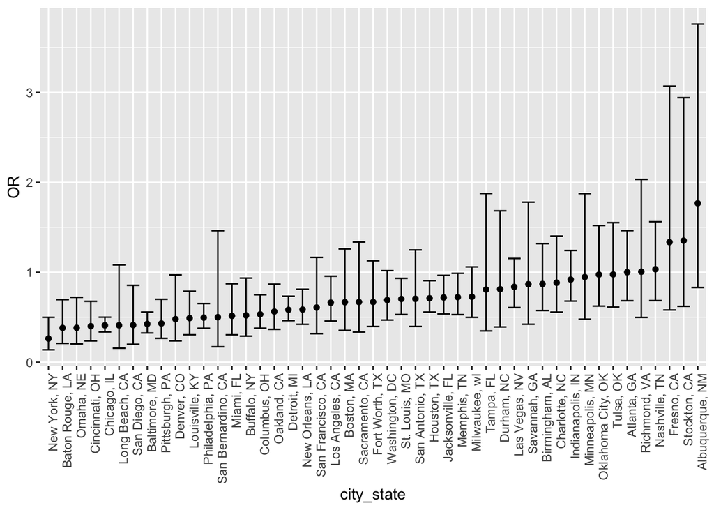

```r
models_results_df %>%
  filter(term == "victim_sexMale") %>%
  mutate(city_state = fct_reorder(city_state, OR)) %>%
  ggplot(aes(x = city_state, y = OR)) +
  geom_point() +
  geom_errorbar(aes(ymin = CI_lower, ymax = CI_upper)) +
  theme(axis.text.x = element_text(angle = 90, hjust = 1))
```

### Problem 2

tidy the birthweight dataset:

```r
bweight_df =
  read_csv("data/birthweight.csv") %>%
  drop_na() %>%
  janitor::clean_names() %>%
  mutate(babysex = as.factor(babysex),
         malform = as.factor(malform),
         )
```

Fit a model:

I started by the hypothesis that baby’s birth weight is associated with a number of predictors including: baby’s sex,presence of malformations that could affect weight (0 = absent, 1 = present), average number of cigarettes smoked per day during pregnancy,gestational age in weeks, mother’s age at delivery (years), mother’s pre-pregnancy BMI. The raw linear model only includes coefficients of main effects.

```r
model_fit = lm(bwt ~ babysex + malform + gaweeks + momage + ppbmi, data = bweight_df) %>%
  broom::tidy()
```

At the significance level of 0.05, there are sufficient evidence to conclude that malform is not a significant predictor for baby’s birthweight. Therefore malform is excluded from my raw model. Rerun the model with remaining predictors:

```r
model1_fit = lm(bwt ~ babysex + gaweeks + momage + ppbmi, data = bweight_df)
```

The estimated correlation coefficients all have p-value<0.05, indicating all predictors are significant at alpha=0.05. Now create a ggplot of model residuals against fitted-values.

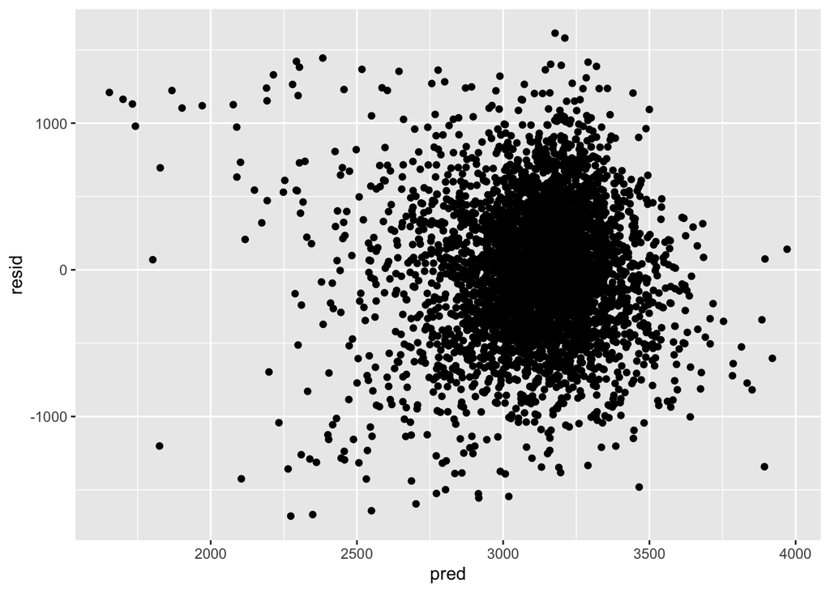

```r
bweight_df %>%
  modelr::add_residuals(model1_fit) %>%
  modelr::add_predictions(model1_fit) %>%
  ggplot(aes(x = pred, y = resid)) +
  geom_point()
```

Build the second using length at birth and gestational age as predictors (main effects only). Build the third model using head circumference, length, sex, and all interactions (including the three-way interaction) between these.

```r
model2_fit = lm(bwt ~ blength + gaweeks, data = bweight_df)
model3_fit = lm(bwt ~ bhead + blength + babysex + bhead * blength + bhead * babysex + blength * babysex + bhead * blength * babysex, data = bweight_df)
```

Compare the 3 models. use mutate + map & map2 to fit models to training data and obtain corresponding RMSEs for the testing data

```r
cv_df =
  crossv_mc(bweight_df, 100) %>%
  mutate(
    train = map(train, as_tibble),
    test = map(test, as_tibble))

cv_df =
  cv_df %>%
  mutate(
    model1_fit  = map(train, ~lm(bwt ~ babysex + gaweeks + momage + ppbmi, data = .x)),
    model2_fit  = map(train, ~lm(bwt ~ blength + gaweeks, data = .x)),
    model3_fit  = map(train, ~lm(bwt ~ bhead + blength + babysex + bhead * blength + bhead * babysex + blength * babysex + bhead * blength * babysex, data = as_tibble(.x)))) %>%
  mutate(
    rmse_1 = map2_dbl(model1_fit, test, ~rmse(model = .x, data = .y)),
    rmse_2 = map2_dbl(model2_fit, test, ~rmse(model = .x, data = .y)),
    rmse_3 = map2_dbl(model3_fit, test, ~rmse(model = .x, data = .y))) %>%

  select(starts_with("rmse")) %>%
  pivot_longer(
    everything(),
    names_to = "model",
    values_to = "rmse",
    names_prefix = "rmse_") %>%
  mutate(model = fct_inorder(model)) %>%
  ggplot(aes(x = model, y = rmse)) + geom_violin()
```

This plot shows the distribution of prediction error for each model

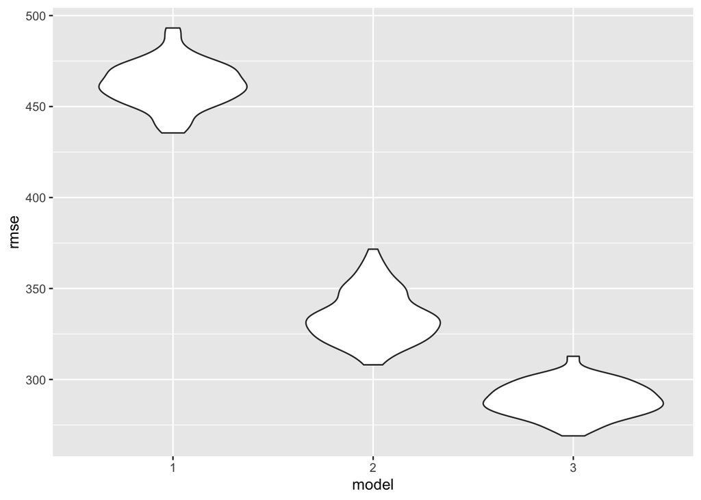

```r
cv_df
```

It is observed that the RMSE decreases significantly in model 3, which indicates that the accuracy of predictive values increases in model 3. Among all of the 3 models, we can conclude that the model 3 using head circumference, length, sex, and all interactions between these produces the most most accurate predicted values.

###Problem 3 Import dataset:

```r
weather_df =
  rnoaa::meteo_pull_monitors(
    c("USW00094728"),
    var = c("PRCP", "TMIN", "TMAX"),
    date_min = "2017-01-01",
    date_max = "2017-12-31") %>%
  mutate(
    name = recode(id, USW00094728 = "CentralPark_NY"),
    tmin = tmin / 10,
    tmax = tmax / 10) %>%
  select(name, id, everything())
```

```
## using cached file: /Users/ymysherry/Library/Caches/R/noaa_ghcnd/USW00094728.dly
```

```
## date created (size, mb): 2020-12-09 21:15:32 (7.536)
```

```
## file min/max dates: 1869-01-01 / 2020-12-31
```

Use 5000 bootstrap samples and, for each bootstrap sample, produce estimates of these two quantities: - r̂ 2 - log(β̂ 0∗β̂ 1)

So we need to build a simple linear regression with tmax as the response and tmin as the predictor, and are interested in the distribution of two quantities estimated from these data.

```r
bootstrap_df =
  weather_df %>%
  modelr::bootstrap(n = 5000) %>%
  mutate(
    models = map(strap, ~lm(tmax ~ tmin, data = .x) ),
    r_results = map(models, broom::glance),
    coe_results = map(models, broom::tidy)) %>%
  select(-strap, -models)
```

```r
r_sqr =
  bootstrap_df %>%
  unnest(r_results) %>%
  select(- coe_results)

r_sqr_plot=
  r_sqr %>%
  ggplot(aes(x = r.squared)) +
  geom_density()

r_sqr %>%
  summarize(
    ci_lower = quantile(r.squared, 0.025),
    ci_upper = quantile(r.squared, 0.975)) %>%
  knitr::kable(digits = 3)
```

| ci_lower | ci_upper |
| --- | --- |
| 0.894 | 0.927 |

1). Note: broom::glance() is helpful for extracting r̂ 2 from a fitted regression, and broom::tidy() (with some additional wrangling) should help in computing log(β̂ 0∗β̂ 1).

Calculate estimated coefficients for log(beta0 * beta1) and its 95% CI.

```r
log_est =
  bootstrap_df %>%
  unnest(coe_results) %>%
  select(- r_results)

beta_0 =
  log_est %>%
  filter(term == "(Intercept)") %>%
  rename(beta0 = estimate) %>%
  select(-term, - p.value, -statistic)

beta_1 =
  log_est %>%
  filter(term == "tmin") %>%
  rename(beta1 = estimate) %>%
  select(-term, - p.value, -statistic)

beta_df =
  merge(
    beta_0,
    beta_1,
    by = ".id"
  ) %>%
  mutate(log_beta = log(beta0 * beta1))

log_beta_plot=
    beta_df %>%
  ggplot(aes(x = log_beta)) +
  geom_density()

beta_df %>%
  summarize(
    ci_lower = quantile(log_beta, 0.025),
    ci_upper = quantile(log_beta, 0.975)) %>%
  knitr::kable(digits = 3)
```

| ci_lower | ci_upper |
| --- | --- |
| 1.966 | 2.058 |